# Mastering factor like a pro

郭耀仁 Yao-Jen Kuo

## Agenda

- TL; DR
- About me
- What is a factor
- How factors confuse R users
- Key takeaways and discussion

## TL; DR

> Factor is an integer vector with a different class name and categorical levels. Factors often confuse R users in ways that they look and sometimes behave like characters, however they are actually integers underneath. In this session, we will talk about how to utilize factors while programming with R.

# About me

## Could that data be any tidier?

[figure not shown]

Source: https://www.pinkvilla.com

## I teach data science

- 台大資工系統訓練班資深講師（授課時數 2000+ 小時）
- 資策會資料工程師養成班（Python 網路爬蟲、R 程式設計）
- 中華電信學院（Python 資料科學、機器學習）
- 2019 華南銀行 Python 資料科學講師
- 2017 玉山銀行 Python 資料科學講師

## I write blogs on Medium

- Follow me on https://medium.com/@tonykuoyj
- Or follow my publications
  - https://medium.com/datainpoint
  - https://medium.com/pyradise

## And collect them into books

- [輕鬆學習R語言：從基礎到應用，掌握資料科學的關鍵能力](https://www.books.com.tw/products/0010835361)
- [進擊的資料科學：Python與R的應用實作](https://www.books.com.tw/products/0010827812)

## Of course, free copies are available online: [DataInPoint](https://www.datainpoint.com/)

## Am also a marathon runner

PR 2:43:12 at 2019 Seoul Marathon

## Previously worked as a …

- Senior Data Analyst at Coupang
- Senior Analytical Consultant at SAS
- Management Associate at CTBC
- Research Intern at McKinsey & Company

# What is a factor

## This is a regular vector

```r
friends_characters <- c("Rachel Green", "Monica Geller", "Phoebe Buffay", "Joey Tribbiani", "Chandler Bing", "Ross Geller")
class(friends_characters)
```

```
## [1] "character"
```

```r
friends_characters
```

```
## [1] "Rachel Green"   "Monica Geller"  "Phoebe Buffay"  "Joey Tribbiani"
## [5] "Chandler Bing"  "Ross Geller"
```

## This is a factor

```r
friends_characters <- factor(c("Rachel Green", "Monica Geller", "Phoebe Buffay", "Joey Tribbiani", "Chandler Bing", "Ross Geller"))
class(friends_characters)
```

```
## [1] "factor"
```

```r
friends_characters
```

```
## [1] Rachel Green   Monica Geller  Phoebe Buffay  Joey Tribbiani
## [5] Chandler Bing  Ross Geller
## 6 Levels: Chandler Bing Joey Tribbiani Monica Geller ... Ross Geller
```

## A factor is a vector that can contain only predefined values and is used to store categorical data

## Factors are built on top of an integer vector with two attributes

- a different class name
- levels

```r
friends_characters <- factor(c("Rachel Green", "Monica Geller", "Phoebe Buffay", "Joey Tribbiani", "Chandler Bing", "Ross Geller"))
str(attributes(friends_characters))
```

```
## List of 2
##  $ levels: chr [1:6] "Chandler Bing" "Joey Tribbiani" "Monica Geller" "Phoebe Buffay" ...
##  $ class : chr "factor"
```

## To be beginner friendly, just think factor as a named integer vector

```r
lvs <- c("Chandler Bing", "Joey Tribbiani", "Monica Geller", "Phoebe Buffay", "Rachel Green", "Ross Geller")
friends_characters <- setNames(1L:6L, lvs)
friends_characters
```

```
##  Chandler Bing Joey Tribbiani  Monica Geller  Phoebe Buffay   Rachel Green
##              1              2              3              4              5
##    Ross Geller
##              6
```

## To be technically correct, we can create a factor from scratch like this

```r
lvs <- c("Chandler Bing", "Joey Tribbiani", "Monica Geller", "Phoebe Buffay", "Rachel Green", "Ross Geller")
friends_characters <- structure(
  1L:6L,
  levels = lvs,
  class = "factor"
)
str(attributes(friends_characters))
```

```
## List of 2
##  $ levels: chr [1:6] "Chandler Bing" "Joey Tribbiani" "Monica Geller" "Phoebe Buffay" ...
##  $ class : chr "factor"
```

## `factor()` function has 2 useful parameters

## The first one would be `levels`

```r
friends_vec <- c("Rachel Green", "Monica Geller", "Phoebe Buffay", "Joey Tribbiani", "Chandler Bing", "Ross Geller")
friends_characters <- factor(friends_vec)
levels(friends_characters) # alphabetical order
```

```
## [1] "Chandler Bing"  "Joey Tribbiani" "Monica Geller"  "Phoebe Buffay"
## [5] "Rachel Green"   "Ross Geller"
```

## `levels` allows users customizing levels of encoding

```r
friends_characters <- factor(friends_vec, levels = friends_vec)
levels(friends_characters) # customized order
```

```
## [1] "Rachel Green"   "Monica Geller"  "Phoebe Buffay"  "Joey Tribbiani"
## [5] "Chandler Bing"  "Ross Geller"
```

## The second one would be `ordered`

```r
friends_characters <- factor(c("Rachel Green", "Monica Geller", "Phoebe Buffay", "Joey Tribbiani", "Chandler Bing", "Ross Geller"))
friends_characters
```

```
## [1] Rachel Green   Monica Geller  Phoebe Buffay  Joey Tribbiani
## [5] Chandler Bing  Ross Geller
## 6 Levels: Chandler Bing Joey Tribbiani Monica Geller ... Ross Geller
```

```r
friends_characters[1] > friends_characters[2]
```

```
## [1] NA
```

## `ordered` makes factor ordinal

```r
friends_characters <- factor(c("Rachel Green", "Monica Geller", "Phoebe Buffay", "Joey Tribbiani", "Chandler Bing", "Ross Geller"), ordered = TRUE)
friends_characters
```

```
## [1] Rachel Green   Monica Geller  Phoebe Buffay  Joey Tribbiani
## [5] Chandler Bing  Ross Geller
## 6 Levels: Chandler Bing < Joey Tribbiani < ... < Ross Geller
```

```r
friends_characters[1] > friends_characters[2] # 5 > 3
```

```
## [1] TRUE
```

# How factors confuse R users

## In base R we tend to encounter factors very frequently

## Common built-in functions for tabular data automatically convert character vectors to factors

- `read.csv()`
- `data.frame()`

## `read.csv()` for importing [Kaggle Titanic](https://kaggle-getting-started.s3-ap-northeast-1.amazonaws.com/titanic/train.csv) as a `data.frame`

```r
df <- read.csv("https://kaggle-getting-started.s3-ap-northeast-1.amazonaws.com/titanic/train.csv")
str(df)
```

```
## 'data.frame':    891 obs. of  12 variables:
##  $ PassengerId: int  1 2 3 4 5 6 7 8 9 10 ...
##  $ Survived   : int  0 1 1 1 0 0 0 0 1 1 ...
##  $ Pclass     : int  3 1 3 1 3 3 1 3 3 2 ...
##  $ Name       : Factor w/ 891 levels "Abbing, Mr. Anthony",..: 109 191 358 277 16 559 520 629 417 581 ...
##  $ Sex        : Factor w/ 2 levels "female","male": 2 1 1 1 2 2 2 2 1 1 ...
##  $ Age        : num  22 38 26 35 35 NA 54 2 27 14 ...
##  $ SibSp      : int  1 1 0 1 0 0 0 3 0 1 ...
##  $ Parch      : int  0 0 0 0 0 0 0 1 2 0 ...
##  $ Ticket     : Factor w/ 681 levels "110152","110413",..: 524 597 670 50 473 276 86 396 345 133 ...
##  $ Fare       : num  7.25 71.28 7.92 53.1 8.05 ...
##  $ Cabin      : Factor w/ 148 levels "","A10","A14",..: 1 83 1 57 1 1 131 1 1 1 ...
##  $ Embarked   : Factor w/ 4 levels "","C","Q","S": 4 2 4 4 4 3 4 4 4 2 ...
```

## `data.frame()` for creating a `data.frame`

```r
friends_cast <- c("Jennifer Aniston", "Courteney Cox", "Lisa Kudrow", "Matt LeBlanc", "Matthew Perry", "David Schwimmer")
friends_characters <- c("Rachel Green", "Monica Geller", "Phoebe Buffay", "Joey Tribbiani", "Chandler Bing", "Ross Geller")
df <- data.frame(
  cast = friends_cast,
  character_names = friends_characters
)
str(df)
```

```
## 'data.frame':    6 obs. of  2 variables:
##  $ cast           : Factor w/ 6 levels "Courteney Cox",..: 3 1 4 5 6 2
##  $ character_names: Factor w/ 6 levels "Chandler Bing",..: 5 3 4 2 1 6
```

## That’s why we often specify `stringsAsFactors` when calling these 2 functions

```r
df <- read.csv("https://kaggle-getting-started.s3-ap-northeast-1.amazonaws.com/titanic/train.csv", stringsAsFactors = FALSE)
str(df)
```

```
## 'data.frame':    891 obs. of  12 variables:
##  $ PassengerId: int  1 2 3 4 5 6 7 8 9 10 ...
##  $ Survived   : int  0 1 1 1 0 0 0 0 1 1 ...
##  $ Pclass     : int  3 1 3 1 3 3 1 3 3 2 ...
##  $ Name       : chr  "Braund, Mr. Owen Harris" "Cumings, Mrs. John Bradley (Florence Briggs Thayer)" "Heikkinen, Miss. Laina" "Futrelle, Mrs. Jacques Heath (Lily May Peel)" ...
##  $ Sex        : chr  "male" "female" "female" "female" ...
##  $ Age        : num  22 38 26 35 35 NA 54 2 27 14 ...
##  $ SibSp      : int  1 1 0 1 0 0 0 3 0 1 ...
##  $ Parch      : int  0 0 0 0 0 0 0 1 2 0 ...
##  $ Ticket     : chr  "A/5 21171" "PC 17599" "STON/O2. 3101282" "113803" ...
##  $ Fare       : num  7.25 71.28 7.92 53.1 8.05 ...
##  $ Cabin      : chr  "" "C85" "" "C123" ...
##  $ Embarked   : chr  "S" "C" "S" "S" ...
```

```r
friends_cast <- c("Jennifer Aniston", "Courteney Cox", "Lisa Kudrow", "Matt LeBlanc", "Matthew Perry", "David Schwimmer")
friends_characters <- c("Rachel Green", "Monica Geller", "Phoebe Buffay", "Joey Tribbiani", "Chandler Bing", "Ross Geller")
df <- data.frame(
  cast = friends_cast,
  character_names = friends_characters,
  stringsAsFactors = FALSE
)
str(df)
```

```
## 'data.frame':    6 obs. of  2 variables:
##  $ cast           : chr  "Jennifer Aniston" "Courteney Cox" "Lisa Kudrow" "Matt LeBlanc" ...
##  $ character_names: chr  "Rachel Green" "Monica Geller" "Phoebe Buffay" "Joey Tribbiani" ...
```

## Factors are useful when we tabulate it

```r
df <- read.csv("https://kaggle-getting-started.s3-ap-northeast-1.amazonaws.com/titanic/train.csv")
embarked_factor <- df$Embarked[1:10]
table(embarked_factor)
```

```
## embarked_factor
##   C Q S
## 0 2 1 7
```

## We can get counts of all categories from factor, even unobserved ones, unlike character

```r
df <- read.csv("https://kaggle-getting-started.s3-ap-northeast-1.amazonaws.com/titanic/train.csv", stringsAsFactors = FALSE)
embarked_chr <- df$Embarked[1:10]
table(embarked_chr)
```

```
## embarked_chr
## C Q S
## 2 1 7
```

## The biggest challenge for R beginners using factor

> Factors look like characters, however they are actually integers in disguise.

## We can use `nchar()` on `character` vectors nice and easy

```r
friends_characters <- c("Rachel Green", "Monica Geller", "Phoebe Buffay", "Joey Tribbiani", "Chandler Bing", "Ross Geller")
nchar(friends_characters)
```

```
## [1] 12 13 13 14 13 11
```

## However, if we apply `nchar()` on `factor` vectors

```r
friends_characters <- factor(c("Rachel Green", "Monica Geller", "Phoebe Buffay", "Joey Tribbiani", "Chandler Bing", "Ross Geller"))
nchar(friends_characters)
```

```
## Error in nchar(friends_characters): 'nchar()' requires a character vector
```

## We can also use `c()` on `character` vectors nice and easy

```r
friends_characters <- c("Rachel Green", "Monica Geller", "Phoebe Buffay", "Joey Tribbiani", "Chandler Bing")
friends_characters <- c(friends_characters, "Ross Geller")
friends_characters
```

```
## [1] "Rachel Green"   "Monica Geller"  "Phoebe Buffay"  "Joey Tribbiani"
## [5] "Chandler Bing"  "Ross Geller"
```

## However, if we apply `c()` on `factor` vectors

```r
friends_characters <- factor(c("Rachel Green", "Monica Geller", "Phoebe Buffay", "Joey Tribbiani", "Chandler Bing"))
friends_characters <- c(friends_characters, "Ross Geller")
friends_characters
```

```
## [1] "5"           "3"           "4"           "2"           "1"
## [6] "Ross Geller"
```

## It seems that factor has tons of disadvantages

## Why does `stringsAsFactors` not default to FALSE

- R was primarily being used by statisticians in the old days
- Because of modeling functions like `lm()` and `glm()`

## R is being used a by a very wide variety of people doing all kinds of things nowadays

Most often, people complaining about factors are people who are doing things that are not the traditional statistical modeling things

## Modeling functions need to treat expand categorical variables into individual dummy variables

```r
df <- read.csv("https://kaggle-getting-started.s3-ap-northeast-1.amazonaws.com/titanic/train.csv")
fit <- glm(Survived ~ Sex, data = df, family = binomial(link = "logit"))
fit$coefficients
```

```
## (Intercept)     Sexmale
##    1.056589   -2.513710
```

## What if we do exactly the same in Python

```python
import pandas as pd
from sklearn.linear_model import LogisticRegression
df = pd.read_csv("https://kaggle-getting-started.s3-ap-northeast-1.amazonaws.com/titanic/train.csv")
X = df["Sex"].values.reshape(-1, 1)
y = df["Survived"].values
lr = LogisticRegression()
lr.fit(X, y)
```

```
## ValueError: could not convert string to float: 'male'
```

## In Python we manually create dummy variables

```python
import pandas as pd
from sklearn.linear_model import LogisticRegression
df = pd.read_csv("https://kaggle-getting-started.s3-ap-northeast-1.amazonaws.com/titanic/train.csv")
X = pd.get_dummies(df["Sex"].values, drop_first=True)["male"].values.reshape(-1, 1)
y = df["Survived"].values
lr = LogisticRegression(solver='lbfgs', penalty='none')
lr.fit(X, y)
print(lr.intercept_)
print(lr.coef_)
```

```
## [1.05659211]
## [[-2.51371812]]
```

## Here’s a question, how does factor relate to one-hot encoding?

## Let’s assume we have to do one-hot encoding from scratch

```r
get_dummies <- function(chr_vector) {
  # A mapping list
  lvs <- sort(unique(chr_vector))
  char_to_int <- list()
  for (i in 1:length(lvs)) {
    list_idx <- lvs[i]
    char_to_int[[list_idx]] <- i
  }
  # One-hot encode
  one_hot_encoded <- data.frame(matrix(0, nrow = length(chr_vector), ncol = length(lvs)))
  colnames(one_hot_encoded) <- lvs
  for (i in 1:length(chr_vector)) {
    list_idx <- chr_vector[i]
    col_idx <- char_to_int[[list_idx]]
    one_hot_encoded[i, col_idx] <- 1
  }
  return(one_hot_encoded)
}
```

```r
df <- read.csv("https://kaggle-getting-started.s3-ap-northeast-1.amazonaws.com/titanic/train.csv")
sex_chr <- as.character(df$Sex)
ohe <- get_dummies(sex_chr)
sex_chr[1:6]
```

```
## [1] "male"   "female" "female" "female" "male"   "male"
```

```r
head(ohe)
```

```
##   female male
## 1      0    1
## 2      1    0
## 3      1    0
## 4      1    0
## 5      0    1
## 6      0    1
```

## We no longer need creating the mapping list ourselves if we have factor in hand

```r
get_dummies <- function(factor_vec) {
  # One-hot encode
  lvs <- levels(factor_vec)
  one_hot_encoded <- data.frame(matrix(0, nrow = length(factor_vec), ncol = length(lvs)))
  colnames(one_hot_encoded) <- lvs
  for (i in 1:length(factor_vec)) {
    col_idx <- as.integer(factor_vec[i])
    one_hot_encoded[i, col_idx] <- 1
  }
  return(one_hot_encoded)
}
```

```r
df <- read.csv("https://kaggle-getting-started.s3-ap-northeast-1.amazonaws.com/titanic/train.csv")
sex_factor <- df$Sex
ohe <- get_dummies(sex_factor)
sex_factor[1:6]
```

```
## [1] male   female female female male   male
## Levels: female male
```

```r
head(ohe)
```

```
##   female male
## 1      0    1
## 2      1    0
## 3      1    0
## 4      1    0
## 5      0    1
## 6      0    1
```

# Key takeaways and discussion

## Factor is built on top of integer

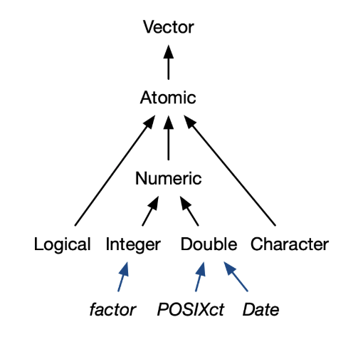

Source: [Advanced R, Second Edition](https://adv-r.hadley.nz/)

## In base R, many base functions use factor as the primary vector types instead of character

## Choosing between character and factor

- In preprocessing stage, use character for non-numerical attributes
- In modeling stage, convert them into factor using `factor()` function

## There are 2 important parameters in `factor()` function

- `levels` allows user to customize encoding order
- `ordered` allows user to create ordinal factor

## Discussion

- Contact me: tonykuoyj@gmail.com
- Follow DataInPoint on Facebook: https://www.facebook.com/datainpoint/